# Statistical Inference

SL

2026-04-23

- [Classical testing theory: Fisher and Neyman-Pearson approaches.](http://127.0.0.1:6262/Notes1.Rmd#section-classical-testing-theory-fisher-and-neyman-pearson-approaches.)
  - [Preliminaries](http://127.0.0.1:6262/Notes1.Rmd#section-preliminaries)
    - [Parametric model](http://127.0.0.1:6262/Notes1.Rmd#section-parametric-model)
    - [Rejection region and error types](http://127.0.0.1:6262/Notes1.Rmd#section-rejection-region-and-error-types)
  - [Power function and Neyman-Pearson theorem](http://127.0.0.1:6262/Notes1.Rmd#section-power-function-and-neyman-pearson-theorem)
    - [Level and size of a test](http://127.0.0.1:6262/Notes1.Rmd#section-level-and-size-of-a-test)
    - [Uniformly most powerful tests](http://127.0.0.1:6262/Notes1.Rmd#section-uniformly-most-powerful-tests)
    - [Neyman-Pearson Lemma](http://127.0.0.1:6262/Notes1.Rmd#section-neyman-pearson-lemma)
  - [Likelihood ratio test](http://127.0.0.1:6262/Notes1.Rmd#section-likelihood-ratio-test)
    - [Generalized likelihood ratio tests](http://127.0.0.1:6262/Notes1.Rmd#section-generalized-likelihood-ratio-tests)
    - [Monotone likelihood ratio](http://127.0.0.1:6262/Notes1.Rmd#section-monotone-likelihood-ratio)
    - [Karlin and Rubin theorem for one-sided tests](http://127.0.0.1:6262/Notes1.Rmd#section-karlin-and-rubin-theorem-for-one-sided-tests)
    - [Two-sided hypotheses](http://127.0.0.1:6262/Notes1.Rmd#section-two-sided-hypotheses)
  - [Unbiased and UMPU tests](http://127.0.0.1:6262/Notes1.Rmd#section-unbiased-and-umpu-tests)
    - [UMPU tests](http://127.0.0.1:6262/Notes1.Rmd#section-umpu-tests)
    - [$\mathscr{C}_m$ tests](http://127.0.0.1:6262/Notes1.Rmd#section-mathscrc_m-tests)
    - [UMP tests in $\mathscr{C}_m$](http://127.0.0.1:6262/Notes1.Rmd#section-ump-tests-in-mathscrc_m)
  - [Confidence sets](http://127.0.0.1:6262/Notes1.Rmd#section-confidence-sets)
    - [Duality between tests and confidence sets](http://127.0.0.1:6262/Notes1.Rmd#section-duality-between-tests-and-confidence-sets)
    - [Pivotal Random Variables](http://127.0.0.1:6262/Notes1.Rmd#section-pivotal-random-variables)
    - [Minimum lenght confidence intervals](http://127.0.0.1:6262/Notes1.Rmd#section-minimum-lenght-confidence-intervals)
  - [Fisher vs Neyman](http://127.0.0.1:6262/Notes1.Rmd#section-fisher-vs-neyman)
    - [P-variables and p-values](http://127.0.0.1:6262/Notes1.Rmd#section-p-variables-and-p-values)
  - [References](http://127.0.0.1:6262/Notes1.Rmd#section-references)

# Classical testing theory: Fisher and Neyman-Pearson approaches.

## Preliminaries

Let us start with a quick review of what a test is. In the common view, an hypothesisis to be tested is defined relative of its *complementary hypothesis*: if the data suggest it is false, what should we believe to be true?

**Def:** The two complementary hypotheses are called *null hypothesis* ($H_0$) and *alternative hypothesis* ($H_1$)

The Null Hypothesis is the hypothesis that is held to be true unless sufficient evidence to the contrary is obtained

In hypothesis testing, the objective is to use data to *decide* if $H_0$ is plausible, or if the evidence does not support it enough and we need to reject it (although it is ofter true that we are actually hoping to reject it).

The definition of a hypothesis test requires the definition of a model (parametric or not) and a specification of the null and alternative hypotheses as submodels.

### Parametric model

For the moment, we consider the case of a parametric model:

$$\left\{ f(\cdot \mid \theta) : \theta \in \Theta
\right\}$$
where $\theta$ is a (possibly vector values) parameter, $\Theta$ is the parameter space, $f(\cdot\mid \theta)$ is a family of distributions (continuous or discrete, univariate or not), indexed by $\theta$.

In this context, a hypothesis can take the form

$$H_0:\theta \in \Theta_0 \quad vs \quad H_1:
\theta \in \Theta_1,$$
where typically (but not necessarily) $\Theta_1 = \Theta\setminus\Theta_0$ is the conjugate of the null parametric set.

We can have simple and composite hypotheses:

- A simple hypothesis determines completely the distribution of $X$, specifies only one possible distribution for the sample (in a parametric framework, it specifies exactly the parameter value). (for example given a Gaussian model with $\sigma^2=1$, the hypothesis, $H_0: \mu=0$)
- a composite hypothesis specifies more that one possible distributions for the sample (for example, given a Gaussian model with $\sigma^2=1$, the hypothesis $H_0: \mu \geq 2$)

### Rejection region and error types

With this setting, we can define:

**Def:** A hypothesis procedure or hypothesis test is a rule that specifies:

> - For which sample values the decision is made to accept $H_0$ as true
> - For which sample values $H_0$ is rejected (and $H_1$ is accepted as true)

The decision is based (typically) on the definition of a **rejection region** (or **critical region**) defined by the subset of the sample space that leads to reject the null hypothesis.

The rejection region $R$ of a hypothesis test is usually defined through a test statistic $W(X)$, a function of the sample

$$R = \{\mathbf{X} : W(\mathbf{X}) > c \} \quad
\Rightarrow \quad reject\; H_0$$
$$A =
\{\mathbf{X} : W(\mathbf{X}) \leq c \} \quad \Rightarrow \quad accept\;
H_0$$
The definition of $R$ as a function of $W$ directly simplifies the definition of $R$, because permits to write it as a subset of $\mathbb{R}$ instead of $\mathbb{R}^n$
$$R_w = \{w : W > c \}$$
Once the region is defined, and a decision (reject or not) is taken, there is no guarantee that it is correct.

#### Errors

In fact, there are 4 possible outcomes of the decision problem, two of which correspond to *wrong decisions*: a type I error occurs if $H_0$ is rejected when it is actually true; a type II error occurs if $H_0$ is not rejected when it is actually false.

| Decision | H0 is true | H1 is true |
| --- | --- | --- |
| H0 | Correct ($1-\alpha$) | Type II error |
| H1 | Type I error ($\alpha$) | Correct |

#### Power function

Errors in hypothesis testing are not symmetric. Conventionally, the statistical testing procedures (both Fisher and Neyman-Pearson) tend to assign a greater importance to $\alpha$, the type I error. This is the error that is controlled for. This is the reason why the null hypothesis is (quite often) defined as the one whose incorrect rejection is considered more severe.

Unfortunately, the two error types enter into conflict: by reducing $\alpha$, the type II error increases, and vice-versa.

#### Example: trade-off between Type I and Type II errors

```r
library(shiny)
library(dplyr)
```

To keep things simple, we assume the same Gaussian population $X \sim N(\mu, \sigma^2)$, $\sigma^2=1$ known and the following simple hypotheses:

$$H_0: \mu=0 \quad vs \quad H_1: \mu =
2$$

The type I and type II errors can’t be both minimized.

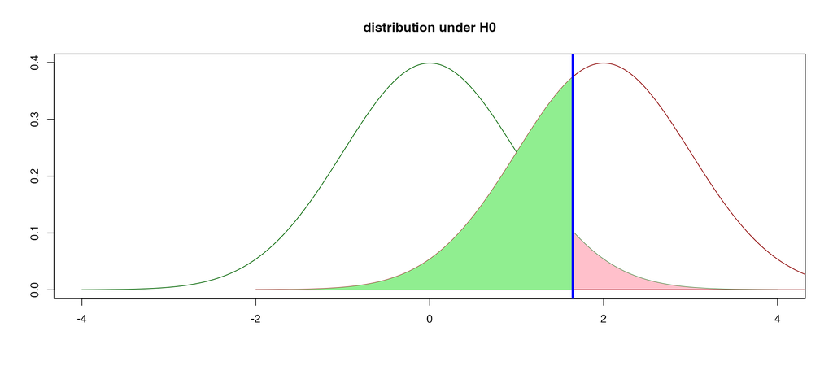

|  | type I error | type II error |
| --- | --- | --- |
| error probabilities | 0.050 | 0.361 |

## Power function and Neyman-Pearson theorem

We now need to recall some definitions

**Def:** A test procedure with rejection region $R$, for the hypothesis

$$H_0: \theta \in \Theta_0 \quad vs \quad H_1:
\theta \in \Theta_1$$
has power function $\beta(\theta)$ defined as:
$$\beta(\theta)=Pr(\mathbf{X} \in R \mid
\theta)$$
for $\theta \in \Theta_0\cup\Theta_1$.

So, the power is the *probability to reject the null hypothesis* given a certain value of $\theta$.

Let $X_1,\ldots,X_{10}$ be a random sample from a population $N(\mu,\sigma^2=4)$ and let

$$H_0:
\mu \leq 0\quad \mbox{and } H_1: \mu > 0$$
and let consider a test with
$$R=\{\bar X
>1\}$$
Then,
$$\begin{eqnarray*}
\beta(\mu)& =&P(\bar X >1\mid \mu=\mu) = P \left(Z >
\frac{1-\mu}{\frac {2}{\sqrt {10}}} \right)
\end{eqnarray*}$$

[figure not shown]

### Level and size of a test

**Def:**

> - For $0 \leq \alpha\leq 1$, a test with *power function* $\beta(\theta)$ is a size $\alpha$ test if
>   $$sup_{\theta \in \Theta_0}
>   \beta(\theta)=\alpha$$
> - For $0 \leq \alpha\leq 1$, a test with power function $\beta(\theta)$ is a level $\alpha$ test if
>   $$sup_{\theta \in \Theta_0} \beta(\theta) \leq
>   \alpha$$

### Uniformly most powerful tests

Fisher advocated the use of a test statistic and look for evidence agaist the null through the *significance level* but was not so concerned about the definition of an optimality procedure that could be valid *universally*.

Neyman and Pearson proposed this resut because they wanted to give a mathematical justification to the tests proposed by Fisher’s procedure.

Since both type I and type II errors can’t be simultaneously minimized, Neyman and Pearson proposed to select the *best* test based on a constrained minimization problem: minimization of Type II error, given the constraint on a fixed Type I error (level) $\alpha$.

They elaborate the concept of Most powerful and Uniformly most powerful (UMP) tests.

**Def:** Let $\mathscr{C}$ be a class of tests for testing $H_0 :\theta \in \Theta_0$ versus $H_1: \theta \in \Theta_1$. A test belonging to a class $\mathscr{C}$ (of possible tests), with power function $\beta(\theta)$, is a uniformly most powerful (UMP) class $\mathscr{C}$ test if, $\beta(\theta) \geq \beta^\prime (\theta)$ for every $\theta \in \Theta_1(=\Theta_0^c)$ and for every $\beta^\prime (\theta)$ that is a power function of a test in class $\mathscr{C}$.

If the chosen family $\mathscr{C}$ is the set of $\alpha$ level tests, then the definition above gives the UMP level $\alpha$ tests.

If $\Theta_0=\{\theta_0\}$ and $\Theta_1=\{\theta_1\}$ (simple hypotheses), then a test satisfying the definition above is said most powerful.

### Neyman-Pearson Lemma

For technical reasons, it is convenient to allow a randomization mechanism, to help with the decision between $H_0$ and $H_1$.

A randomized test is characterized by a *critical function* $\phi$ with range in $[0,1]$. Given $\boldsymbol x$, $\phi(\boldsymbol x)$ is the probability to reject $H_0$.

In this case, the power function corresponds to the expectation of the critical function with respect to a given parameter:

$$\beta(\theta) = E_\theta
P_\theta\left\{\mbox{reject $H_0$} \mid X \right\} = \text{E}_\theta
\phi(X)$$
Note that the set of critical functions $\Phi$ is convex: if $\phi_1$ and $\phi_2$ are critical function (belong to $\Phi$), then for any $\tau \in (0,1)$, also $\tau \phi_1 +(1-\tau)\phi_2 \in \Phi$.

A nonrandomized test is a randomized test where $R=\{x: \phi(x)=1\}$.

**Theorem (Neyman-Pearson (1933))** Consider testing $H_0 :\theta =\theta_0$ versus $H_1: \theta=\theta_1$ where the pdf or pmf corresponding to $\theta_i$ is $f( \boldsymbol x \mid \theta_i),\,i=0,1$.

1. There exist a test $\phi$ and a constant $k$ such that
   $$E_{\theta_0} \phi(X)=\alpha \qquad \quad
   \mbox{and}$$
   $$\phi(x)=\left\{
   \begin{array}{ll}
   1 & \mbox{when } f(x\mid \theta_1)>k f(x\mid \theta_0)\\
   0 & \mbox{when } f(x\mid \theta_1)<k f(x\mid \theta_0)
   \end{array}
   \right.$$
2. If a test satisfies the above conditions for some $k$, then it is most powerful for testing $\theta_0$ against $\theta_1$
3. If $\phi$ is most powerful, then there exists $k$ such that $\phi$ is defined as above (a.e.) unless there exists a test with size $<\alpha$ and power 1.

**Remark** If $\phi \in \{0,1\}$ (nonrandomized test), the Neyman-Pearson Lemma states that every most powerful level $\alpha$ test, if it exists, must have the rejection region:

$$R=\{\boldsymbol x: \,
f(\boldsymbol x\mid \theta_1)\geq k f (\boldsymbol x \mid
\theta_0)\}$$

for some $k>0$ for which $P_{\theta_0}(\boldsymbol X \in R)=\alpha$.

Also, if a test with rejection region $R$ as above exists and $P_{\theta_0}(\boldsymbol X \in R)=\alpha$ exists, then the UMP $\alpha-$level test is a size $\alpha$ test.

**Proof** 1- Let $\alpha(k)=P_{\theta_0}\{f(x\mid \theta_1)>k f(x\mid \theta_0)\}$. Assume $f(x\mid \theta_0)>0$ (the probability is computed under $H_0$). $\alpha(k)$ is the probability that the rv $f(X\mid \theta_1)/f(X\mid \theta_0)>k$. Thus, $1-\alpha(k)$ is a CDF (not necessarily continuous), with $\alpha(k^-)-\alpha(k)=P_{\theta_0}\left(f(X\mid \theta_1)/ f(X\mid \theta_0)=k\right)$.

Given $\alpha \in (0,1)$, let $k_0$ be such that $\alpha(k_0)\leq \alpha \leq \alpha(k_0^-)$ and define

$$\phi(x)=\left\{ \begin{array}{ll}
1 & \mbox{when } f(x\mid \theta_1)>k_0 f(x\mid \theta_0)\\
\frac{\alpha-\alpha(k_0)}{\alpha(k_0^-)-\alpha(k_0)} & \mbox{when }
f(x\mid \theta_1)=k_0 f(x\mid \theta_0)\\
0 & \mbox{when } f(x\mid \theta_1)<k_0 f(x\mid \theta_0)
\end{array}
\right.$$

If $\alpha(k_0^-)-\alpha(k_0)=0$, then $P_{\theta_0}\left\{ f(x\mid \theta_1)=k_0 f(x\mid \theta_0)\right\}=0$ and $\phi$ is defined a.e.

It is easy to see that the size of the test is $E_{\theta_0}\phi(X)=\alpha$

2- Suppose that $\phi$ satisfies the definition of the theorem, and assume $\phi^*$ is any other test with $E_{\theta_0}\phi^*\leq \alpha$.

Let

$$S_+ = \{x : \phi(x)-\phi^*(x)>0\}
\quad \mbox{and}\quad S_-=\{\phi(x)-\phi^*(x)<0\}$$

If $x \in S_+$, then necessarily $\phi(x)>0$ and thus $f(x\mid \theta_1)\geq k f(x\mid \theta_0)$. If $x \in S_-$, then necessarily $\phi(x)<1$ and thus $f(x\mid \theta_1)\leq k f(x\mid \theta_0)$.

Thus,

$$\begin{split}
& \int (\phi(x)-\phi^*(x)) (f(x\mid \theta_1)-kf(x\mid \theta_0) )dx
=\cr
& \qquad \int_{S_+\cup S_-} (\phi(x)-\phi^*(x)) (f(x\mid
\theta_1)-kf(x\mid \theta_0) )dx \geq 0 \end{split}$$
and this implies
$$\begin{split}\beta_\phi(\theta_1)-\beta_{\phi^*}(\theta_1)
& =E_{\theta_1}\phi(X)- E_{\theta_1}\phi^*(X) \cr & =\int
(\phi(x)-\phi^*(x)) f(x\mid \theta_1) dx \cr
& \geq \int (\phi(x)-\phi^*(x)) kf(x\mid \theta_0) dx \geq 0
\end{split}$$

3- See (Lehmann and Romano 2022)

**Example** Suppose $X\sim binomial(2,\theta)$ and we are interested in testing $H_0: \theta=1/2$ vs $H_1:\theta=3/4$.

The likelihood ratio

$$L(X)=\frac{f_{3/4}(X)}{f_{1/2}(X)} =
\frac{{2\choose X} (3/4)^X(1/4)^{2-X}}{{2\choose X}
(1/2)^2}=\frac{3^X}{4} \stackrel{\tiny\mbox{(under $H_0$)}}{=} \left\{
\begin{array}{ll}
1/4 & pr. \;1/4\\
3/4 & pr. \; 1/2\\
9/4 & pr. \; 1/4
\end{array}
\right.$$

Assume $\alpha=0.05$ is the desired level.

We have $P_{\theta_0}(L(X)\leq 3/4) = 3/4 < 1-\alpha$, thus $k>3/4$, but if $k<9/4$, then $P_{\theta_0}(L(X)>k) =P_{\theta_0}(L(X)=9/4) = 1/4 > \alpha$, thus $k \geq 9/4$.

However, $k>9/4$ is also impossible, because then $P_{\theta_0}(L(X)>k)=0$ (implying $\phi=0$).

Thus, we must have $k=9/4$ and $\phi(0)=\phi(1)=0$, while $\phi(2)$ is determined by:

$$\alpha = E_{\theta_0} \phi(X) =
\frac{1}{4}\phi(2) \quad \Rightarrow \phi(2)=4 \alpha .$$

From factorization theorem, it is easy to derive:

**Corollary** Consider testing $H_0 :\theta =\theta_0$ versus $H_1: \theta =\theta_1$. Suppose $T(\boldsymbol{X})$ is a sufficient statistics for $\theta$ and $g(t|\theta_i),\,i=0,1$ is its prob. density function corresponding to $\theta_i$. Then any test statistics based on $T$ with rejection region $S$ is a most powerful level $\alpha$ test if it satisfies

$$t=T(\boldsymbol x) \in S\quad if \,
g(t|\theta_1)>k g(t|\theta_0)$$
and
$$t=T(\boldsymbol x) \in S^C \quad if \,
g(t|\theta_1) < k g(t|\theta_0)$$
and
$$\alpha=P_{\theta_0}(T \in S)$$

**Example** $X\sim exponential(\lambda)$ and

$$H_0:
\lambda=1 \quad vs \quad H_1:\lambda=2$$
The rejection region must be defined as:
$$R= \{ \boldsymbol x: k
e^{-\sum_i x_i} < 2^{n}e^{-2\sum_i x_i}\}$$
where $k$ is such that
$$\begin{split}P\left(X \in R\mid \lambda=1 \right)
&= P_{1}\left( k \, e^{-\sum_i X_i} < 2^{n}e^{-2\sum_i X_i}
\right)\cr &
= P_1\left(e^{\sum_i X_i} < 2^{n}/k\right) \cr & =
P_1\left(\sum_i X_i < n\log 2-\log(k) \right) = \alpha
\end{split}$$

Since $\sum_i X_i\sim Gamma(n,1)$, one can find $k$.

[figure not shown]

## Likelihood ratio test

According to N-P Lemma, test of the form:

$$R=\left\{\boldsymbol x : \frac{f(\boldsymbol
x\mid \theta_1)}{f(\boldsymbol x\mid \theta_0)}\geq k\right\}$$
is an MP test of level $\alpha= P_{\theta_0}(\boldsymbol X \in R)$ (unless the event $\left\{ \frac{f(\boldsymbol x\mid \theta_1)}{f(\boldsymbol x\mid \theta_0)} = k\right\}$ has positive probabilty, in that case randomization is necessary).

The region $R$ is defined as the ratio between the likelihood function under the alternative and the likelihood function under the null hypothesis.

This is very simple because NP Lemma only considers simple hypothesis (both for $H_0$ and $H_1$).

This suggests the definition of likelihood ratio tests for arbitrary testing problems.

### Generalized likelihood ratio tests

Suppose we have

$$H_0: \theta \in \Theta_0
\quad vs \quad H_1: \theta \in \Theta_o^c$$
The values fof $\theta$ under $H_0$ and $H_1$ are not unique

However, suppose that the MLE exists over the whole parameter space $\Theta=\Theta_0\cup\Theta_0^c$

We can also obtain the MLE for $\theta$ under the null hypothesis (through constrained optimization):

$$\hat{\theta}_0 =
\arg\max_{\theta \in \Theta_0} \ell(\theta\mid \boldsymbol x)=
\arg\max_{\theta \in \Theta_0} \log f(\boldsymbol x \mid
\theta)$$
Then, we take the ratio between the likelihood under $H_0$, $f(\boldsymbol x \mid \hat{\theta}_0)$ and the likelihood under the parameter space $\Theta$ (that is the unconstrained MLE):
$$\hat{\theta} = \arg\max_{\theta \in \Theta}
\ell(\theta\mid \boldsymbol x)$$

The (generalized) likelihood ratio test statistic is then:

$$\lambda(\boldsymbol x)= \frac{\max_{\theta \in
\Theta} L({\theta}\mid \boldsymbol x)}{\max_{\theta \in \Theta_0}
L({\theta}\mid \boldsymbol x)} = \frac{L(\hat{\theta}\mid \boldsymbol
x)}{L(\hat{\theta_0}\mid \boldsymbol x)} = \frac{f(\boldsymbol x \mid
\hat{\theta})}{f(\boldsymbol x \mid \hat{\theta}_0)}$$

- In typical situations, only one of the optimizations is constrained
- The numerator is always larger than the denominator (only equal to 1 if $\hat{\theta}_0=\hat{\theta}$)
- The smaller the ratio, the larger the evidence in favor of the null
- The larger the ratio, the larger the evidence against the null

The *likelihood ratio test* (LRT) is any test that has a rejection region of the form : $\{\boldsymbol{x}: \lambda(\boldsymbol{x}) \geq c\}$ where $c$ is any number satisfying $c>1$.

### Monotone likelihood ratio

To generalize the optimality result of Neyman and Pearson to non-simple hypotheses, we need to introduce the following:

**Def:** A family of pdfs $\{f(x\mid \theta); \, \theta \in \Theta\}$ has monotone likelihood ratio if there exists a function $T(x)$ such that whenever $\theta_2>\theta_1$, the ratio

$$\frac{f(t\mid
\theta_2)}{f(t\mid\theta_1)}$$
is a nondecreasing function of $t=T(x)$ on
$$\mathscr{x}=\{t:\,f(t\mid \theta_1)>0 \;\;
\mbox{or} \;\; f(t\mid\theta_2)>0\}.$$
Further, the distribution is identifiable, that is $g(t; \theta_1)\neq g(t; \theta_2)$ whenever $\theta_1\neq \theta_2$

**Example** The exponential family

$$f(x\mid \theta) = \exp\left\{ w(\theta)t(x)
-b(\theta)\right\}h(x)$$
if $w(\theta)$ strictly increasing has likelihood ratio monotone in $T=t(x)$.

**Example** Another example of MLR distributions are location families with densities $g(x-\theta)$ for which $-log g$ is convex. (See example 1 Ch.9 Lehmann (1986))

### Karlin and Rubin theorem for one-sided tests

Consider the one-sided composite test

$$H_0: \theta \leq \theta_0 \quad
\mbox{vs} \quad H_1: \theta>\theta_0$$

**Theorem (Karlin and Rubin)** Suppose that $X$ has density $f(x\mid \theta)$ with monotone likelihood ratio in $T(x)$. Then:

1. The test $\phi^*$ defined by

   $$\phi^*(x)=\left\{\begin{array}{ll}
   1 & T(x)>c\\
   \gamma & T(x)=c\\
   0 & T(x)<c
   \end{array}\right.$$
   is a uniformly most powerful (UMP) level $\alpha$ test where $\alpha =E_{\theta_0} \phi^*$.

   The constants $c$ and $\gamma$ can be adjusted to attain the desired significance level.
2. The power function of $\phi^*$ is nondecreasing, strictly increasing if $0<\beta(\theta)<1$

**Proof**

*Power is nondecreasing.* Suppose $\theta_1<\theta_2$ and set

$$L(x)=\frac{f(x\mid \theta_2)}{f(x\mid
\theta_1)}=\frac{g(T(x)\mid \theta_2)}{g(T(x)\mid \theta_1)}$$
By assumption, $L$ is a nondecreasing function of $T(x)$. Let $k$ be such that $(T=c) \mapsto (L=k)$. Then
$$\phi^*(x)=\left\{\begin{array}{ll}
1 & L>k\\
0 & L<k
\end{array}\right.$$
is a likelihood ratio test for the simple hypothesis $H_0: \theta=\theta_1$ vs $H_1: \theta=\theta_2$. By the corollary to the N-P Lemma, this test is most powerful and thus (see Corollary 12.4. (Keener 2010)) $E_{\theta_1} \phi^* \leq E_{\theta_2} \phi^*$ (with strict inequality unless both expetations are either 0 or 1).

So, $\phi^*$ has level

$$\sup_{\theta \leq \theta_0} E_{\theta}\phi^*(X)=
E_{\theta_0} \phi^*(X) = \alpha$$
and nondecreasing power as stated in 2.

*$\phi^*$ is UMP*

It remains to show that any test $\tilde{\phi}$ such that $E_{\theta_0} \tilde{\phi}(X) \leq \alpha$ has lower power than $\phi^*$.

Take an arbitrary $\theta_1>\theta_0$. From the NP Lemma, $\phi^{*}$ is the most powerful test for the simple hypothesis $H_0: \theta = \theta_{0}$ against the alternative $H_1: \theta = \theta_{1}$, thus implying $E_{\theta_1}\phi^*\geq E_{\theta_1}\tilde{\phi}$

**Choice of $c$ and $\gamma$**

Finally, we show that $c$ nd $\gamma$ can be chosen so that $E_{\theta_0}\phi^*=\alpha$. Let $G_0$ be the CDF of $T(X)$ when $\theta=\theta_0$. Let $c=\sup\{t: G_0(t)\leq 1-\alpha\}$.

- If $t=T(x)>c$, then $G_0(t)>1-\alpha$.
- $G_0$ is right continuous, so $\quad G_0(c) = \lim_{t\downarrow c} G_0(t) \geq 1-\alpha$
- For $t<c$, $\quad G_0(t)\leq 1-\alpha\quad$ and $\quad G_0(c^-) = \lim_{t\uparrow c} G_0(t) \leq 1-\alpha$
- Define

  $$\gamma=\frac{G_0(c)-(1-\alpha)}{G_0(c)-G_0(c^-)}=\frac{G_0(c)-(1-\alpha)}{P_{\theta_0}(T=c)}$$
  (note that if $G_0(c)-G_0(c^-)=0$, then $\gamma$ need not to be defined).
- Finally,

  $$E_{\theta_0}\phi^* = \gamma
  P_{\theta_0}(T=c) + 1\cdot P_{\theta_0}(T>c) = G_0(c)-(1-\alpha) +
  (1-G_0(c))=\alpha$$

### Two-sided hypotheses

This example is to show that there can’t be a UMP test in the case of two-sided alternatives.

Consider the hypothesis

$$H_0:
\theta=\theta_0 \mbox{ vs } H_1: \theta \neq \theta_0,$$
where $\theta$ is the population mean from a Gaussian family with known variance $\sigma^2$.

- Suppose we define a test with $R_1(\boldsymbol X)=\{T(\boldsymbol X)\leq t_0\}$
  $$\alpha=P(\bar{X}\leq t_0\mid
  \theta_0) = P\left(\frac{\bar{X}-\theta_0}{\sigma/\sqrt{n}}\leq
  \frac{t_0-\theta_0}{\sigma/\sqrt{n}}\right)$$
  Then, $\frac{t_0-\theta_0}{\sigma/\sqrt{n}} = z_{\alpha}\Rightarrow t_0=\theta_0 + z_\alpha\frac{\sigma}{\sqrt{n}} = \theta_0 - z_{1-\alpha}\frac{\sigma}{\sqrt{n}}$

And, by Karlin-Rubin, this test is UMP for

$$H_0: \theta = \theta_0 \quad vs \quad H_1:
\theta < \theta_0 .$$

- Repeat the same reasoning with $R_2(\boldsymbol X)=\{ T(\boldsymbol X)\geq t_0\}$, we get

  $$\alpha=P(\bar{X}\geq
  t_0\mid \theta_0) = P\left(\frac{\bar{X}-\theta_0}{\sigma/\sqrt{n}}\geq
  \frac{t_0-\theta_0}{\sigma/\sqrt{n}}\right)$$
  Now $t_0=\theta_0 + z_{1-\alpha}\frac{\sigma}{\sqrt{n}}=\theta_0 - z_{\alpha}\frac{\sigma}{\sqrt{n}}$ is UMP for
  $$H_0: \theta = \theta_0 \quad vs \quad H_1:
  \theta > \theta_0 .$$
- The power of the test based on $R_1$ is

  $$\beta_1(\theta)= P_\theta\left( \bar{X}<
  \theta_0 - z_{1-\alpha}\frac{\sigma}{\sqrt{n}} \right)=
  P_\theta\left(\frac{\bar{X}-\theta}{\sigma/\sqrt{n}}<
  \frac{\theta_0-\theta}{\sigma/\sqrt{n}}-z_{1-\alpha}\right)$$
- The power of the test based on $R_2$ is

  $$\beta_2(\theta)= P_\theta\left( \bar{X}>
  \theta_0 + z_{1-\alpha}\frac{\sigma}{\sqrt{n}} \right)=
  P_\theta\left(\frac{\bar{X}-\theta}{\sigma/\sqrt{n}}>
  \frac{\theta_0-\theta}{\sigma/\sqrt{n}}+z_{1-\alpha}\right)$$
- Let $\theta^\prime>\theta_0$, then

  $$\begin{split}\beta_1(\theta^\prime) & =
  P_{\theta^\prime}\left(\frac{\bar{X}-\theta^\prime}{\sigma/\sqrt{n}}\leq
  \frac{\theta_0-\theta^\prime}{\sigma/\sqrt{n}}-z_{1-\alpha}\right) =
  \Phi\left(\frac{\theta_0-\theta^\prime}{\sigma/\sqrt{n}}-z_{1-\alpha}\right)
  \cr
  & < \Phi\left(-z_{1-\alpha}\right)=
  1-\Phi\left(z_{1-\alpha}\right) < 1-
  \Phi\left(\frac{\theta_0-\theta^\prime}{\sigma/\sqrt{n}}+z_{1-\alpha}\right)
  = \beta_2(\theta^\prime)
  \end{split}$$
- Similarly, for $\theta^\prime<\theta_0$, $\beta_2(\theta^\prime)<\beta_1(\theta^\prime)$, so there is no UMP

## Unbiased and UMPU tests

- The reason why in many cases we can’t find the UMP test is that the class $\mathscr{C}$ of level-$\alpha$ tests is too large.
- We can compromise by restricting the class of tests we consider to compare the power functions in the a subclass of *unbiased* test statistics

**Def:** A test for the hypothesis

$$\theta \in \Theta_0 \quad vs \quad \theta \in
\Theta_0^c$$
with power function $\beta(\theta)$ is called if
$$\beta(\theta^\prime) \geq \beta(\theta'')
\quad \mbox{for all $\theta^\prime \in \Theta_0^c$ and $\theta''
\in \Theta_0$}$$

- An unbiased test must reject a false hypothesis (any $\theta^\prime \in \Theta_0^c$) with a probability larger than the probability to reject a true hypothesis ($\theta'' \in \Theta_0$).
- If $\alpha= \sup_{\theta \in \Theta_0}\beta(\theta)$ is the size of the unbiased test, then

  $$\beta(\theta)\geq \alpha, \quad \mbox{for
  all } \theta \in \Theta_0^c.$$
- *A test that is uniformly most powerful among all umbiased tests is called an UMPU test*

### UMPU tests

- UMPU tests for the two-sided hypothesis
  $$H_0: \theta=\theta_0 \quad \mbox{vs}\quad H:1
  \theta \neq \theta_0$$
  exist for exponential families.

**Theorem** Let $\alpha \in (0,1)$ and $\theta_0 \in int(\Theta)$. If $X$ has a distribution of the form

$$f(x\mid \theta) =
c(\theta) h(x) \exp\left\{t(x) w(\theta)\right\}$$
with $\infty > w'(\theta_0) >0$. Then there exists a uniformly most powerful unbiased test $\phi^*$ of level $\alpha$, satisfying $\beta'(\theta_0)=0$

- $\phi^*$ is a two-sided test: namely takes the form
  $$\phi=\left\{\begin{array}{cc}
  1 & (T<t_l)\cup(T>t_u)\\
  0 & t_l<T<t_u \end{array}\right.$$
  and $\min\{E\phi 1\{T \leq t_l\},E\phi 1\{T \geq t_u\}\}>0$.

### $\mathscr{C}_m$ tests

The previous theorem comes as a corollary case of the following more general result:

- Let $\phi^+$ and $\phi^-$ be thw UMP tests for the one-sided alternatives $\theta>\theta_0$ and $\theta<\theta_0$ with powers $\beta_+(\theta)$ and $\beta_-(\theta)$.
- From UMP property of $\phi^+$ and $\phi_-$ it is easy to see that for any test $\phi$,

  $$m_-=:\beta_-'(\theta_0)\leq
  \beta_{\phi}'(\theta_0) \leq \lim_{\varepsilon \downarrow
  0}\frac{\beta_{+}(\theta_0+\varepsilon)-\beta_{+}(\theta_0)}{\varepsilon}=\beta'_+(\theta_0):=m_+$$
- Now, denote $\mathscr{C}_m$ the class of level $\alpha$ tests such that $\beta_{\phi}'(\theta_0)=m$
- Note that unbiased tests must have $m=0$: suppose for example $m<0$, then $\beta'_{\phi}(\theta_0)=m$ and $\beta_{\phi}$ is decreasing at $\theta_0$. Thus, for $\theta' >\theta_0$, we get $\beta_{\phi}(\theta')<\beta_\phi(\theta_0)$, that contradicts unbiasedness, because $\theta' \in \Theta_1$

### UMP tests in $\mathscr{C}_m$

**Theorem (th.12.22 in Keener, 2010)** Let $\alpha \in (0,1)$ and $\theta_0 \in int(\Theta)$. If $X$ has a distribution of the form

$$f(x\mid \theta) = c(\theta) h(x) \exp\left\{t(x)
w(\theta)\right\}$$
with $\infty > w'(\theta_0) >0$. If $m \in (m_-,m_+)$ there exists a UMP level $\alpha$ test in $\mathscr{C}_m$, say $\phi^*$.

$\phi^*$ is a two-sided test.

- It is easy to see that (th, 12.20 Keener (2010)), for the exponential family as above:
  $$\beta'_\phi(\theta)= w'(\theta) E_\theta
  (T\phi)+d(\log c(\theta))E_\theta \phi$$

**Example** Let $X \sim exponential(\theta)$: $f(x \mid \theta)= \theta e^{-\theta x}$ for $x>0$.

Consider testing $H_0: \theta=1$ vs $H_1:\theta\neq 1$ based on one observation only.

The UMPU test then has the form:

$$\phi=\left\{\begin{array}{cc}
1 & (X<t_l)\cup(X>t_u)\\
0 & t_l<X<t_u \end{array}\right.$$
where $t_u,t_l$ must satisfy
$$E_1 \phi = 1- \int_{t_l}^{t_u} e^{-x}dx = 1-
e^{-t_l}-e^{-t_u}=\alpha$$
with the constraint $\beta'_\phi(\theta_0)=0$, that implies
$$0=w'(1) E_1 \phi X + d(\log(c(1)) E_1
\phi = 1-\int_{t_l}^{t_u} xe^{-x}dx + \stackrel{\alpha}{\overbrace{E_1
\phi}}$$
Putting the two equations together:
$$t_l e^{-t_l}
=-(e^{-t_l}-1+\alpha)\log\left(e^{-t_l}-1+\alpha\right)$$
The solution has to be found numerically.

Solving for $P(X\leq t_l)=P(X>t_u)=\alpha/2$ simplifies the computation, but in this case the test is biased, because $m(\theta_0)=\beta'_\phi(\theta_0)\neq 0$

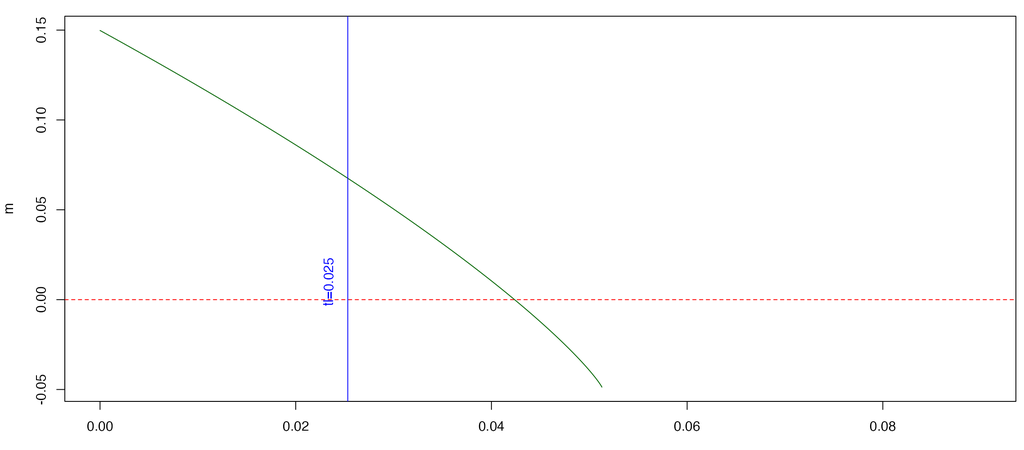

## Confidence sets

### Duality between tests and confidence sets

Tests and confidence intervals a have a one-2-one correspondence:

Recall that a random set $S(X)$ is a $1-\alpha$ confidence region for a parameter $\theta$ if

$$P_\theta(\theta \in S(X))\geq 1-\alpha, \forall
\theta \in \Theta.$$

- Let $\phi$ be a level $\alpha$ binary test with acceptance region $A(\theta_0)$ for the hypothesis $\theta=\theta_0$.

Then the region $S(X)=\{\theta: X \in A(\theta)\}$ is a $1-\alpha$ confidence region. In fact:

$$P_\theta(\theta
\in S(X))=P_\theta(X\in A(\theta))\geq 1-\alpha$$

- Conversely, given the $1-\alpha$ confidence region $S$, the test

  $$\phi(X)=\left\{\begin{array}{cc} 1 & \theta_0
  \in S(X)^c\\
  0 & \theta_0 \in S(X)\end{array}\right.$$
  is a level $\alpha$ test for $\theta=\theta_0$ against $\theta\neq \theta_0$.
- Optimality of tests should correspond to optimal confidence interval (in some sense).
- Consider a confidence set $S(X)$ defined as the inverse of a binary two-sided test $\phi$ (we assume for convenience $\Theta =(\theta_l,\theta_u)$ with $\max(|\theta_l|,|\theta_u|) = \infty$ allowed).
- Let $\lambda(A)$ be the Lebesgue measure of the set $A$. The average length of the confidence interval $S$ based on the test $\phi$ is:

  $$\begin{split}E_\theta
  \lambda(S(X)\setminus\{\theta\} ) & = E_\theta \int_{\Theta
  \setminus \{\theta\} } 1\{\theta_0 \in S(X)\}d\theta_0 =
  \int_{\mathscr{X}}\int_{\Theta \setminus \{\theta\}} 1\{\theta_0 \in
  S(X)\}d\theta_0 dP_{\theta}(x)\cr & = \int_{\Theta \setminus
  \{\theta\}} P_\theta(\theta_0 \in S(X)) d\theta_0 = \int_{\Theta
  \setminus \{\theta\}} P_\theta(X \in A(\theta_0)) d\theta_0
  \cr & =\int_{\Theta \setminus \{\theta\}}
  (1-\beta(\theta_0))d\theta_0\end{split}$$
  Since a UMP(U) test $\phi^*$ maximizes $\beta^*(\theta_0)$ for all $\theta_0\neq \theta$, the mean length of the corresponding confidence set $S^*$ is
  $$E_\theta \lambda(S(X)\setminus\{\theta\})\geq
  E_\theta \lambda(S^*(X)\setminus\{\theta\})$$

**Example** Let $X \sim exponential(\lambda)$ (with $\lambda=E X$). Suppose we want a confidence interval for $\lambda$.

We can obtain it by inverting a LR test for

$$H_0 : \lambda= \lambda_0 \quad vs \quad H_1:
\lambda \ne \lambda_0$$

Le LRT statistic is:

$$\lambda(\boldsymbol
x)=\frac{\lambda_0^{-1} \exp\{-\sum_i
x_i/\lambda_0\}}{\sup_{\lambda>0} \lambda^{-1} \exp\{-\sum_i
x_i/\lambda\}}=\frac{\lambda_0^{-1} \exp\{-\sum_i
x_i/\lambda_0\}}{\bar{x}^{-1} \exp\{-\sum_i x_i/\bar{x}\}} =
\left(\frac{\bar{x}}{\lambda_0}\right)^n
e^{\frac{-n\bar{x}}{\lambda_0}+n}$$

Rejection region is for small values of $\lambda (\boldsymbol x)$

So, acceptance region is

$$A(\lambda_0) =
\left\{\boldsymbol x: \, \left(\frac{\bar{x}}{\lambda_0}\right)^n
e^{-n(\bar{x}/\lambda_0-1)} \geq k \right\}$$
where $k$ is defined implicitly by $P_{\lambda_0}\left(\boldsymbol X \not \in A(\lambda_0) \right)=\alpha.$

Then, we obtain the confidence interval:

$$\begin{split}
CI(\boldsymbol x) &= \left\{\lambda:
\left(\frac{\bar{x}}{\lambda}\right)^n e^{-n(\bar{x}/\lambda-1)} \geq k
\right\} = \left\{\lambda: \left(\frac{\bar{x}}{\lambda}\right)^n
e^{-n\bar{x}/\lambda} \geq k e^{-n} \right\}
\end{split}$$

[figure not shown]

### Pivotal Random Variables

**Def.:** A random variable $Q(\boldsymbol X,\theta)$ is a **pivotal quantity** (or pivot) if its distribution does not depend on the parameter $\theta$. Here $\boldsymbol {X}$ is the random sample.

- If the pivotal quantity can be inverted as a function of $\theta$ for each value of $\boldsymbol X$ , then we may find a confidence region (interval) for $\theta$.
- Inversion means that, for each $\boldsymbol x$ and each subset $A$ of the range of $Q(\boldsymbol x,\theta)$, there exists a subset $R(\boldsymbol x, A)$ of $\Theta$ such that
  $$Q(\boldsymbol x,\theta) \in A \,
  \Longleftrightarrow \, \theta \in R(\boldsymbol x,A)$$
  This implies that
  $$P(Q(\boldsymbol X,\theta) \in
  A)=P(\theta \in R(\boldsymbol X,A))$$
- From a (nontrivial) pivotal random variable one can often obtain a confidence interval
- In general there may be more than one pivotal random variable and confidence intervals

### Minimum lenght confidence intervals

An optimality theorem for confidence intervals is available for unimodal distributions.

**Theorem(9.3.2 Casella and Berger (2024))** Assume $T=T(X)$ is a pivotal statistic for $\theta$ and that its distribution $f(t)$ is unimodal. If in the interval $[a,b]$ satisfies

1. $\int_a^b f(t)dt=1-\alpha$
2. $f(a)=f(b)>0$
3. $a \leq t^{\star} \leq b$ where $t^{\star}$ is a mode for $f(t)$

Then $[a,b]$ is the **shortest among all intervals** that satisfies $\int_a^b f(t)dt=1-\alpha$.

**Example (continued)**

sample size

10

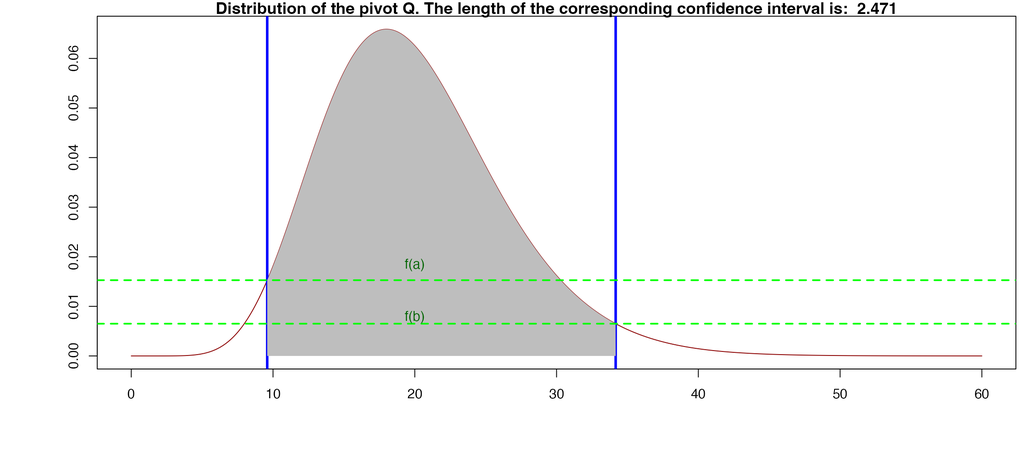

## Fisher vs Neyman

- The approach outlined so far follows Neyman-Pearson hypothesis testing framework: the problem of testing is treated as a decision problem.
- Neyman-Pearson wanted to find a mathematical justification to the significance tests of the Fisher school.
- Even so, Fisher was quite adamant in opposing their approach.
> - Fisher refused the idea of the *optimality* as a property of a procedure, and claimed the central role of the experience of the research in making an informed decision conditional on the problem
> - Therefore, maximization of power is not relevant. Fisher is not very much interested in the alternative: a large value of the test statistic gives evidence against the null, because it makes less plausible the null hypothesis (low probability to observe that value under the null)
- The approach outlined so far follows Neyman-Pearson hypothesis testing framework: the problem of testing is treated as a decision problem.
- Neyman-Pearson wanted to find a mathematical justification to the significance tests of the Fisher school.
- Even so, Fisher was quite adamant in opposing their approach.
- While for N-P, the choice based on optimality is pre-experimental, for Fisher every conclusion (significance level) must be conditional on an available distribution constant. N-P principle is coherent with the idea of repetibility of the experiment
- Sometimes the contrast is also referred as c contrast between p-values (or significance) and *pre-determined $\alpha$ level*.

### P-variables and p-values

Let us consider the null hypothesis $\Theta_0$.

**Def:** A $p-$variable for $\Theta_0$ is a $[0,1]-$valued random variable $U$ such that, for every $\alpha \in (0,1)$, and for all $\theta \in \Theta_0$:

$$P_{\theta}(U\leq \alpha)\leq \alpha$$
The $p-$variable is exact if $P_{\theta}(U\leq \alpha)= \alpha$.

**Def:** A $p-$value is the value taken by the $p-$variable on observing the data.

A test that rejects $H_0: \theta \in \Theta_0$ if and only if $U=U(\boldsymbol X)\leq \alpha$ is a level $\alpha$ test by construction.

A test result can be reported via its $p-$value rather than the acceptance/rejection decision. This clearly gives more information, because it reports the result of the test on a continuous scale.

**Theorem** Let $\phi$ be a one-sided test with rejection region $R(\theta)=\{T(\boldsymbol X)\geq k\}$. Define for each sample point $\boldsymbol x$, the function

$$p(\boldsymbol x) = \sup_{\theta \in \Theta_0}
P_\theta (T(\boldsymbol X)\geq T(\boldsymbol x))$$
Then, the r.v. $p(\boldsymbol X)$ is a $p-$variable.

**Proof.** For any $\theta_0 \in \Theta_0$

$$p_{\theta_0}(\boldsymbol x)=P_{\theta_0}
(T(\boldsymbol X)\geq T(\boldsymbol x)) =P_{\theta_0} (-T(\boldsymbol
X)\leq -T(\boldsymbol x)) = F_{\theta_0}(-T(\boldsymbol x))$$
where $F_{\theta_0}$ is the CDF of $-T(\boldsymbol X)$ under $\theta_0$. Then, by the probability integral transform, $F_{\theta_0}(-T(\boldsymbol X))\stackrel{d}{=}p_{\theta_0}(\boldsymbol X) \sim U(0,1)$.

Thus, for any $\alpha \in (0,1)$, $P_{\theta} \left(p(\boldsymbol X)\leq \alpha\right)=P_{\theta} \left(\sup_{\theta } p_{\theta}(\boldsymbol X)\leq \alpha\right) \leq P_{\theta} \left(p_{\theta}(\boldsymbol X)\leq \alpha\right)=\alpha$

## References

Casella, G., and R. Berger. 2024. *Statistical Inference*. Chapman & Hall.

Keener, Robert W. 2010. *Theoretical Statistics. Topics for a Core Course*. Springer.

Lehmann, E. L. 1986. *Testing Statistical Hypotheses*. Springer Texts in Statistics. Springer.

Lehmann, E. L., and Joseph P. Romano. 2022. *Testing Statistical Hypotheses*. Springer. https://doi.org/10.1007/978-3-030-70578-7.